# WHO Measles Outbreak Investigation

Research Question

What socioeconomic factors have an effect on Measles infection rate? Are these socioeconomic factors correlated with vaccine coverage rate?

Global Annual Measles Cases Rates per Million

| **Year** | **Region** | **Avg. Measles per Million** | **Avg. Pop.** |
| --- | --- | --- | --- |
| 2016 | Western Pacific | 383.71 | 75,481,528 |
| 2015 | Western Pacific | 285.78 | 74,982,984 |
| 2014 | Western Pacific | 261.30 | 74,471,085 |
| 2019 | Africa | 215.77 | 24,840,386 |
| 2024 | Europe | 162.43 | 18,086,400 |
| 2019 | Europe | 128.55 | 17,970,197 |
| 2023 | Eastern Mediterranean | 103.08 | 38,309,144 |
| 2024 | Eastern Mediterranean | 97.66 | 35,118,436 |
| 2018 | Europe | 96.67 | 17,902,651 |
| 2022 | Eastern Mediterranean | 96.60 | 37,587,428 |
| 2017 | Eastern Mediterranean | 92.14 | 36,004,856 |
| 2018 | Eastern Mediterranean | 86.73 | 36,643,827 |
| 2023 | Europe | 86.43 | 20,889,680 |
| 2015 | Europe | 82.53 | 18,225,035 |
| 2025 | Europe | 79.19 | 20,367,336 |
| 2023 | Africa | 73.52 | 28,092,125 |
| 2025 | Eastern Mediterranean | 72.66 | 35,759,886 |
| 2022 | Africa | 72.02 | 27,399,968 |
| 2019 | Western Pacific | 70.27 | 73,801,758 |
| 2019 | Eastern Mediterranean | 70.24 | 37,308,464 |
| 2024 | Africa | 64.28 | 29,448,224 |
| 2016 | Africa | 60.99 | 24,062,145 |
| 2015 | Africa | 54.39 | 23,436,840 |
| 2013 | Europe | 52.82 | 17,804,446 |
| 2020 | Africa | 51.73 | 27,167,320 |
| 2014 | Africa | 38.41 | 22,847,137 |
| 2018 | Africa | 38.41 | 25,323,858 |
| 2012 | Eastern Mediterranean | 38.04 | 30,211,296 |
| 2014 | Europe | 37.41 | 18,124,818 |
| 2025 | Africa | 34.01 | 30,588,330 |

[output cut: 52 more lines]

Data is arranged is descending order by Average Measles Cases per Million.

Global Measles Cases in 2024

[interactive chart not shown]

Average Measles Cases Rates per Million Heatmap

[interactive chart not shown]

**Average MCV1 Coverage**

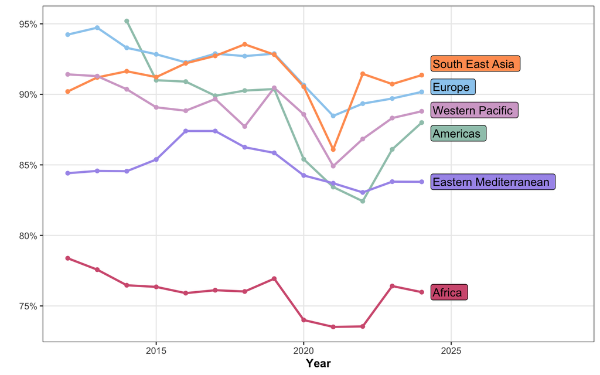

**Correlations Between Demographic Variables**

| Region | MCV1 vs GDP | MCV1 vs Measles | GDP vs Measles |
| --- | --- | --- | --- |
| Africa | −0.167 | −0.167 | −0.010 |
| Americas | 0.090 | 0.090 | 0.004 |
| Eastern Mediterranean | 0.397 | 0.397 | −0.137 |
| Europe | 0.127 | 0.127 | −0.084 |
| South East Asia | 0.017 | 0.017 | 0.164 |
| Western Pacific | 0.230 | 0.230 | −0.038 |

**MCV1 Coverage vs. GDP Plot - Regional**

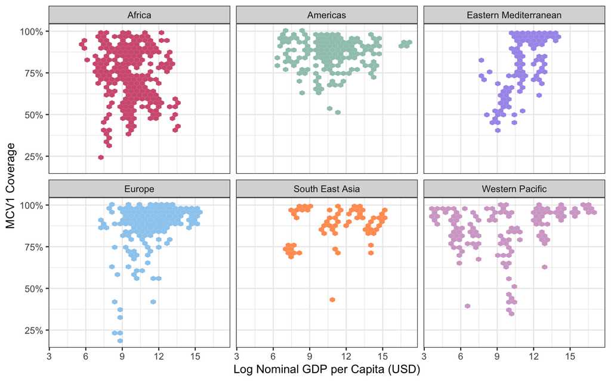

Motivations for Romania, a representative case.

Based on our Global Annual Measles Cases Rates per Million table and accompanying heatmap, we observed that the Western Pacific region had the highest measles cases per million between 2014 and 2016. However, the most recent data from 2024 shows that Europe now leads in measles cases per million. Focusing on Europe, we found that Romania is an informative case: its population of 19.07 million is roughly representative of the region, and it reported the largest total measles cases and the third highest average cases in Europe 2024, making it an interest for further analysis.

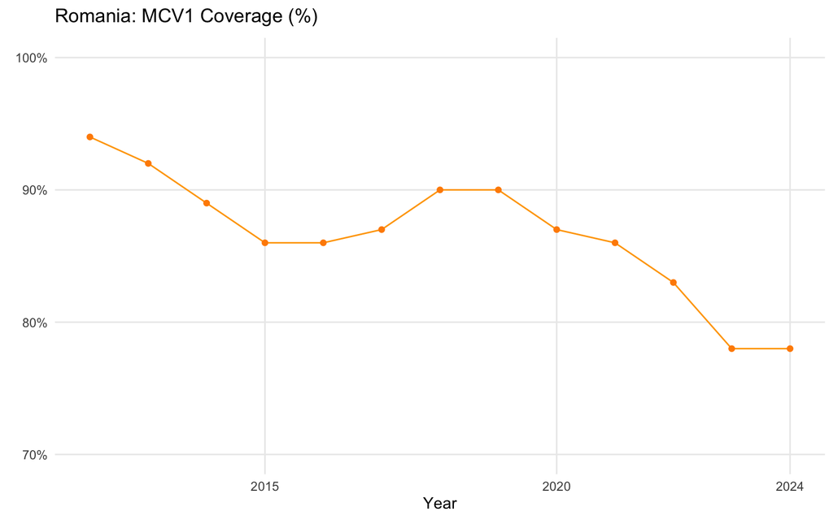

**Infant Mortality Rate**

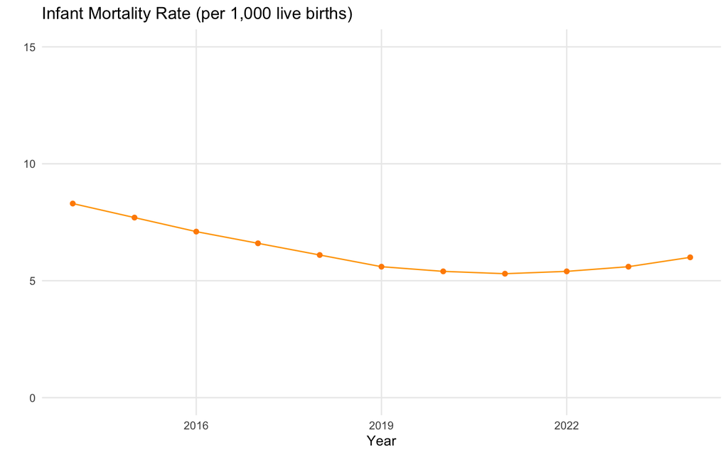

**GDP per Capita**

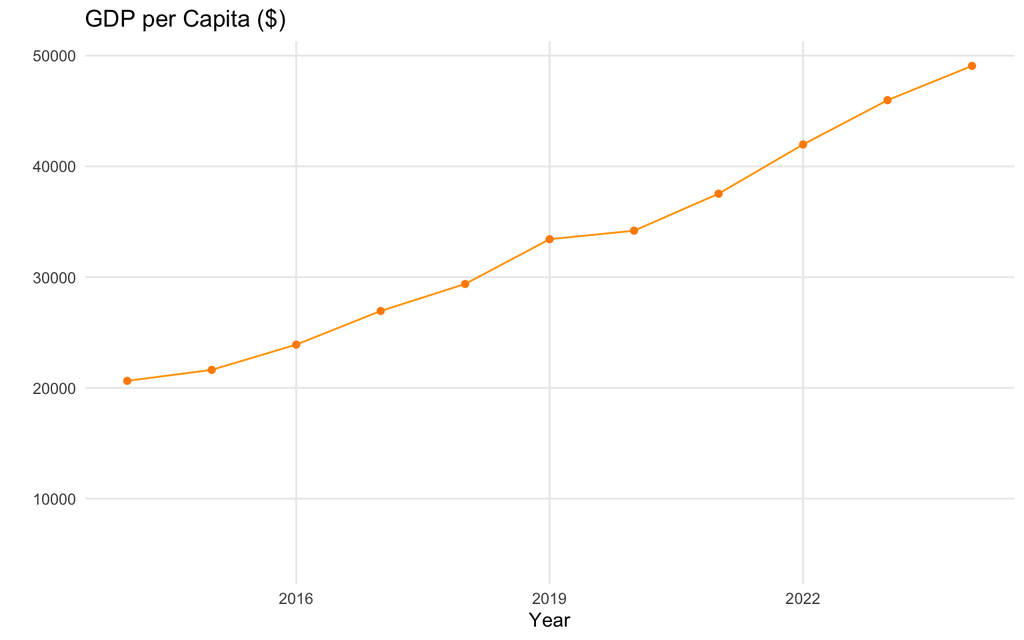

**Poverty Headcount at $3.00 a day**

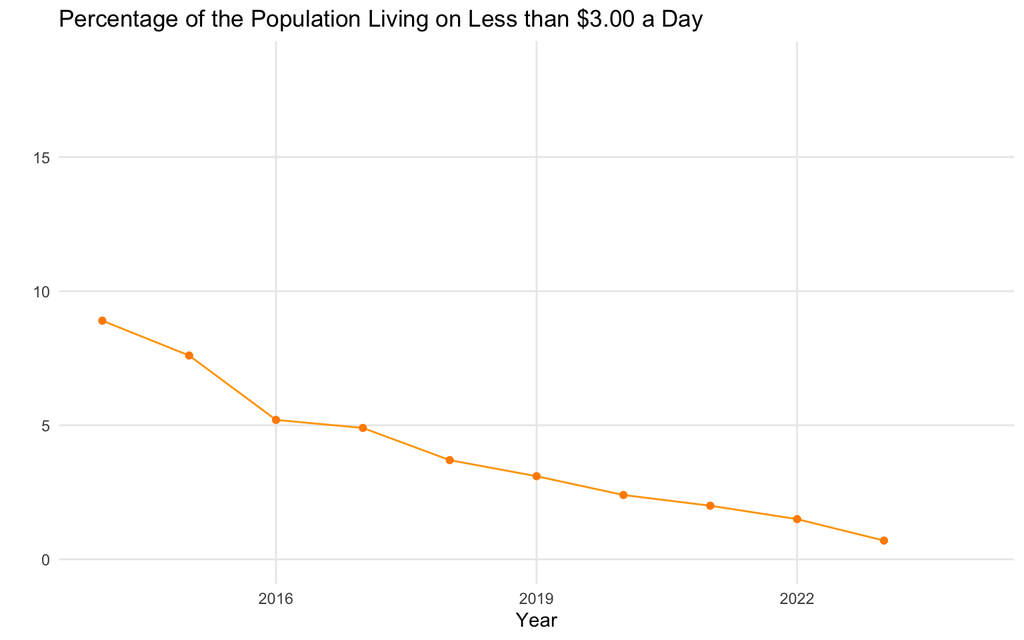

Exploratory Findings